# Customized Retirement Portfolio Optimization

**Tools:** Python, NumPy, Pandas, Dynamic Programming, Monte Carlo Simulation  
**Date:** December 2024

## 1. Project Overview

This project develops a quantitative model to generate **personalized retirement investment advice** for clients with comparable income growth and savings behavior. The objective is to identify the **optimal portfolio allocation strategy** that maximizes each client’s expected lifetime utility, given their financial profile and market uncertainty.

Using **stochastic dynamic programming** and a **shortfall-based utility function**, the model determines the best portfolio mix annually until retirement, accounting for investment constraints, employer matching, and age-dependent salary growth. Simulated correlated market outcomes yield a **dynamic policy** adaptable to individual situations.

## 2. Problem Context

### 2.1 Client Profiles

| Client Name | Current Age | Account Balance (USD) |
| --- | --- | --- |
| Amy Abrams | 52 | 500,000 |
| Bob Brown | 55 | 400,000 |
| Carla Clausen | 57 | 900,000 |
| Darrin Dorne | 57 | 500,000 |
| Eric Evans | 62 | 1,100,000 |
| Francine Farnsworth | 65 | 950,000 |

Each client plans to retire at **age 67**.

### 2.2 Client Assumptions

- **Savings Rate:** 10 % of salary
- **Employer Match:** 6 % of salary
- **Total Annual Contribution:** 16 % (added at start of each year)
- **Retirement Spending Goal:** 80 % of pre-retirement income
  - 30 % covered by Social Security/other income
  - 50 % funded by portfolio withdrawals

**Salary Model:**
$$ \text{Salary at age } x = 60{,}000 + (x - 27) \times 1{,}000 $$

### 2.3 Portfolio Choices

Investments are limited to 8 diversified **balanced fund mixes** with varying exposure to asset classes:

| Asset Class | Mix 1 | Mix 2 | Mix 3 | Mix 4 | Mix 5 | Mix 6 | Mix 7 | Mix 8 |
| --- | --- | --- | --- | --- | --- | --- | --- | --- |
| US Stock | 30% | 25% | 25% | 23% | 21% | 16% | 13% | 8% |
| Developed Intl. | 30% | 25% | 21% | 19% | 15% | 12% | 9% | 6% |
| Emerging Markets | 10% | 10% | 8% | 6% | 4% | 4% | 2% | 1% |
| Global REIT | 10% | 10% | 8% | 6% | 5% | 4% | 3% | 2% |
| US Aggregate Bond | 10% | 20% | 30% | 40% | 45% | 50% | 55% | 51% |
| Hedge Funds | 10% | 10% | 8% | 6% | 5% | 4% | 3% | 2% |
| Cash | 0% | 0% | 0% | 0% | 5% | 10% | 15% | 30% |

### 2.4 Market Model

Assuming stationary and based on long-term empirical data, each asset class has expected real returns and volatilities, with correlations distribution:

| Asset | Mean Return | Std. Dev. |
| --- | --- | --- |
| US Stock | 6.0% | 19.1% |
| Dev. Intl Stock | 5.9% | 20.2% |
| Emerging Markets | 7.0% | 26.8% |
| Global REIT | 5.6% | 20.7% |
| US Aggregate Bond | 1.9% | 3.8% |
| Hedge Funds | 5.2% | 7.0% |
| Cash | 1.5% | 5.8% |

**Correlation Matrix**

|  | US Stock | Dev. Int’l | Emer. Mkt | Global RE | US Agg | Hedge Fund | Cash |
| --- | --- | --- | --- | --- | --- | --- | --- |
| US Stock | 1.00 | 0.74 | 0.67 | 0.74 | 0.13 | 0.47 | 0.02 |
| Dev. Int’l | 0.74 | 1.00 | 0.70 | 0.78 | 0.09 | 0.46 | 0.00 |
| Emer. Mkt | 0.67 | 0.70 | 1.00 | 0.66 | 0.07 | 0.45 | -0.03 |
| Global RE | 0.74 | 0.78 | 0.66 | 1.00 | 0.10 | 0.37 | -0.03 |
| US Agg | 0.13 | 0.09 | 0.07 | 0.10 | 1.00 | 0.10 | 0.10 |
| Hedge Fund | 0.47 | 0.46 | 0.45 | 0.37 | 0.10 | 1.00 | 0.55 |
| Cash | 0.02 | 0.00 | -0.03 | -0.03 | 0.10 | 0.55 | 1.00 |

A full 7x7 correlation matrix defines relationships among these returns.

## 3. Optimization Approach

### 3.1 Objective Function

The optimization objective is to maximize expected utility of terminal wealth $U(x)$ at retirement. We penalize falling short of retirement goals while rewarding surplus wealth. Each client’s **utility** of retirement wealth (x) is defined using a shortfall-based function:

$$ U(x) = \begin{cases} (1.2 \times T)^{0.2} x^{0.8} & x > 1.2T \\\ x - \gamma (1.2T - x)^2 & 0.8T \le x \le 1.2T \\\ -15840 + 15x - \gamma (0.4T)^2 & x < 0.8T \end{cases} $$

where $T$ = target balance to sustain 3.5% withdrawal rate, $ \gamma = 0.02 $ is the risk aversion parameter. This piecewise form reflects a utility that penalizes shortfalls below 80% of the target while capping marginal benefits above 120% of the target.

### 3.2 Dynamic Programming Formulation

Dynamic programming works **backwards** from retirement, computing expected utilities for discrete wealth levels and ages. For each (age, wealth) pair, the optimal mix is stored, creating a **policy map**.

## 4. Python Implementation

### 4.1 Overview

The Python implementation defines parameters, client data, and utility functions, and constructs a **dynamic programming engine** that solves for optimal fund selection at each age/wealth combination.

```python
import numpy as np
import pandas as pd
import matplotlib.pyplot as plt
import seaborn as sns

##############################
# GLOBAL PARAMETERS          #
##############################
RETIREMENT_AGE = 67
GAMMA = 0.02

# Asset class parameters (annualized, real returns)
mean = np.array([0.06, 0.059, 0.07, 0.056, 0.019, 0.052, 0.015])
stdev = np.array([0.191, 0.202, 0.268, 0.207, 0.038, 0.07, 0.058])
correlation_matrix = np.array([
    [1.00, 0.74, 0.67, 0.74, 0.13, 0.47, 0.02],
    [0.74, 1.00, 0.70, 0.78, 0.09, 0.46, 0.00],
    [0.67, 0.70, 1.00, 0.66, 0.07, 0.45, -0.03],
    [0.74, 0.78, 0.66, 1.00, 0.10, 0.37, -0.03],
    [0.13, 0.09, 0.07, 0.10, 1.00, 0.10, 0.10],
    [0.47, 0.46, 0.45, 0.37, 0.10, 1.00, 0.55],
    [0.02, 0.00, -0.03, -0.03, 0.10, 0.55, 1.00]
])

covariance = np.dot(np.dot(np.diag(stdev), correlation_matrix), np.diag(stdev))

# 8 diversified fund mixes (portfolio choices)
funds = np.array([
    [0.30, 0.30, 0.10, 0.10, 0.10, 0.10, 0.00],
    [0.25, 0.25, 0.10, 0.10, 0.20, 0.10, 0.00],
    [0.25, 0.21, 0.08, 0.08, 0.30, 0.08, 0.00],
    [0.23, 0.19, 0.06, 0.06, 0.40, 0.06, 0.00],
    [0.21, 0.15, 0.04, 0.05, 0.45, 0.05, 0.05],
    [0.16, 0.12, 0.04, 0.04, 0.50, 0.04, 0.10],
    [0.13, 0.09, 0.02, 0.03, 0.55, 0.03, 0.15],
    [0.08, 0.06, 0.01, 0.02, 0.51, 0.02, 0.30]
])

clients = [
    {"name": "Amy Abrams", "age": 52, "current_savings": 500},
    {"name": "Bob Brown", "age": 55, "current_savings": 400},
    {"name": "Carla Clausen", "age": 57, "current_savings": 900},
    {"name": "Darrin Dorne", "age": 57, "current_savings": 500},
    {"name": "Eric Evans", "age": 62, "current_savings": 1100},
    {"name": "Francine Farnsworth", "age": 65, "current_savings": 950}
]
```

Here is a rough risk/ return chart for all my 8 mixes

```python
# Calculate the expected return and standard deviation for each mix
expected_returns = funds @ mean
risks = np.sqrt(np.einsum('ij,jk,ik->i', funds, covariance, funds))

# Combine results for display
results = pd.DataFrame({
  "Mix": [f"Mix {i+1}" for i in range(len(funds))],
  "Expected Return (%)": expected_returns * 100,
  "Risk (Std Dev %)": risks * 100
})
print(results)
```

```
     Mix  Expected Return (%)  Risk (Std Dev %)
0  Mix 1                5.540         15.250498
1  Mix 2                5.135         13.504678
2  Mix 3                4.733         11.963448
3  Mix 4                4.329         10.473542
4  Mix 5                3.895          8.830912
5  Mix 6                3.480          7.309757
6  Mix 7                3.045          5.812985
7  Mix 8                2.539          4.399015
```

```python
##############################
# SUPPORT FUNCTIONS          #
##############################

def salary(age: int) -> float:
    """Return annual salary in thousands as a linear function of age."""
    return 60 + (age - 27)

def annual_saving(age: int) -> float:
    """Return total annual saving (employee + employer match) in thousands."""
    return 0.16 * salary(age - 1)

target = 0.5 * 99 / 0.035  # Target wealth to sustain 3.5% withdrawal rate


def utility(x: float) -> float:
    """Piecewise shortfall-based utility function."""
    if x > 1.2 * target:
        return (1.2 * target) ** 0.2 * (x ** 0.8)
    elif x >= 0.8 * target:
        return x - GAMMA * (1.2 * target - x) ** 2
    else:
        return -15840 + 15 * x - GAMMA * ((1.2 - 0.8) ** 2 * target ** 2)


def simulate_scenarios(fund: np.ndarray, wealth: float, N: int) -> np.ndarray:
    """Simulate wealth growth across N scenarios given portfolio weights."""
    returns = np.random.multivariate_normal(mean, covariance, size=N)
    total_ret = returns @ fund
    return wealth * (1 + total_ret)
```

### 4.2 Dynamic Programming Formulation

DP iterates backward from retirement age to determine the fund maximizing expected future utility at each grid point.

```python
##############################
# DYNAMIC PROGRAMMING ENGINE #
##############################

def retirement_dp(step: int, N: int):
    """Backward dynamic programming to determine optimal fund per age/wealth grid."""
    wealth_levels = np.arange(0, 5000, step)
    N_age = RETIREMENT_AGE - 52 + 1
    DP_util = np.full((N_age, len(wealth_levels)), -np.inf)
    DP_choice = np.zeros_like(DP_util, dtype=int)

    # Terminal utility at retirement
    for w_i, w_val in enumerate(wealth_levels):
        DP_util[0, w_i] = utility(w_val)

    # Backward induction
    for age_idx in range(1, N_age):
        current_age = RETIREMENT_AGE - age_idx
        for w_i, current_wealth in enumerate(wealth_levels):
            best_util, best_fund = -np.inf, 0
            for f_i, fund in enumerate(funds):
                next_wealth = simulate_scenarios(fund, current_wealth, N)
                next_idx = np.clip(np.floor(next_wealth / step).astype(int), 0, len(wealth_levels) - 1)
                exp_util = DP_util[age_idx - 1, next_idx].mean()
                if exp_util > best_util:
                    best_util, best_fund = exp_util, f_i
            DP_util[age_idx, w_i] = best_util
            DP_choice[age_idx, w_i] = best_fund
    return wealth_levels, DP_util, DP_choice


def interpolate_solution(age, wealth, retirement_age, wealth_levels, DP_util, DP_choice):
    """Linear interpolation of utility/fund for smoother wealth transitions."""
    age_idx = retirement_age - age
    if wealth <= wealth_levels[0]:
        return DP_util[age_idx, 0], DP_choice[age_idx, 0]
    if wealth >= wealth_levels[-1]:
        return DP_util[age_idx, -1], DP_choice[age_idx, -1]

    w_i = np.searchsorted(wealth_levels, wealth) - 1
    fraction = (wealth - wealth_levels[w_i]) / (wealth_levels[w_i + 1] - wealth_levels[w_i])
    util = (1 - fraction) * DP_util[age_idx, w_i] + fraction * DP_util[age_idx, w_i + 1]
    fund = DP_choice[age_idx, w_i if DP_util[age_idx, w_i] > DP_util[age_idx, w_i + 1] else w_i + 1]
    return util, fund


def find_client_strategy(client, DP_util, DP_choice, wealth_levels, step):
    """Trace optimal path for a given client through DP results."""
    age, wealth = client['age'], client['current_savings']
    strategy = []
    while age < RETIREMENT_AGE:
        _, fund = interpolate_solution(age, wealth, RETIREMENT_AGE, wealth_levels, DP_util, DP_choice)
        strategy.append((age, wealth, fund + 1))
        wealth += annual_saving(age)
        wealth *= (1 + mean @ funds[fund])
        age += 1
    return strategy
```

Visualization modules display utility contours, wealth trajectories, and optimal fund transitions. Together they illustrate how the model adapts investment strategy with age and wealth.

```python
##############################
# VISUALIZATION HELPERS      #
##############################

def plot_utility_surface(DP_util, wealth_levels, title="Utility Contours"):
    df = pd.DataFrame(DP_util, columns=wealth_levels, index=range(67, 51, -1))
    plt.figure(figsize=(10, 6))
    cp = plt.contourf(df.columns, df.index, df.values, 25, cmap='RdYlGn')
    plt.colorbar(cp, label="Utility")
    plt.title(title, fontsize=13, fontweight='bold')
    plt.xlabel("Wealth ($k)")
    plt.ylabel("Age")
    plt.show()

def plot_fund_heatmap(df, title="Dynamic Programming – Optimal Fund Choice by Age"):
    pivot = df.pivot(index="Client", columns="Age", values="Fund Mix")
    plt.figure(figsize=(8, 4))
    sns.heatmap(pivot, cmap="YlGnBu", annot=True, fmt=".0f", cbar_kws={'label': 'Fund Mix'})
    plt.title(title, fontsize=13, fontweight='bold')
    plt.xlabel("Age")
    plt.ylabel("Client")
    plt.tight_layout()
    plt.show()

def plot_client_growth(df, title="Projected Wealth Growth by Client"):
    plt.figure(figsize=(7, 5))
    for name, group in df.groupby("Client"):
        plt.plot(group["Age"], group["Wealth (k$)"], marker='o', label=name)
    plt.title(title, fontsize=13, fontweight='bold')
    plt.xlabel("Age")
    plt.ylabel("Wealth ($k)")
    plt.legend()
    plt.grid(True, linestyle="--", alpha=0.6)
    plt.tight_layout()
    plt.show()
```

### 4.3 Simulation and Visualization

Monte Carlo simulations of multivariate returns estimate wealth distributions under different strategies.  
Visualization modules display:

- **Utility surfaces** (contours by age × wealth)
- **Wealth trajectories** for each client
- **Optimal fund heatmaps** illustrating portfolio shifts over time

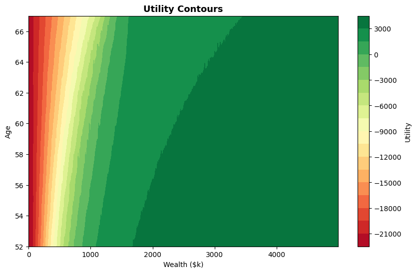

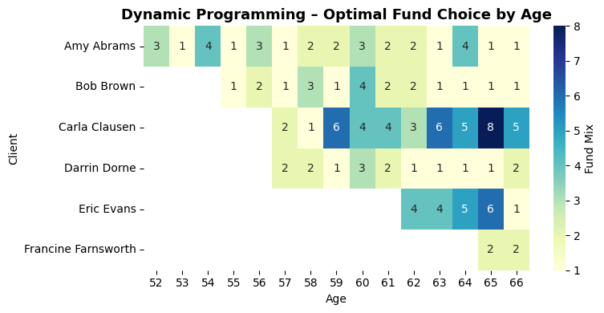

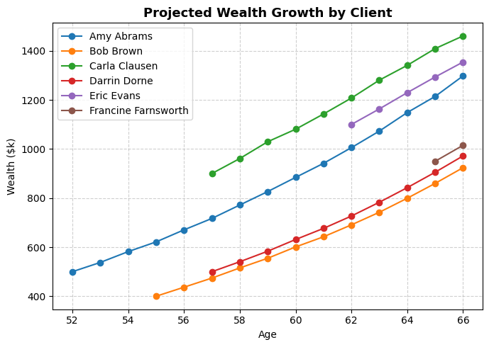

```python
step, N = 10, 100
wealth_levels, DP_util, DP_choice = retirement_dp(step, N)

records = []
for client in clients:
    strategy = find_client_strategy(client, DP_util, DP_choice, wealth_levels, step)
    for age, wealth, fund in strategy:
        records.append({"Client": client["name"], "Age": age, "Wealth (k$)": wealth, "Fund Mix": fund})

df = pd.DataFrame(records)

plot_utility_surface(DP_util, wealth_levels)
plot_fund_heatmap(df)
plot_client_growth(df)
```

#### Refined DP Calculation with Smaller Step Size

By changing the step size from 10 to 5 and keep the number of scenarios ($N$) as 100, we increase the resolution of the wealth grid and the accuracy of scenario simulations. Smaller step sizes provide more detailed states and can lead to more precise and stable optimal strategies, at the cost of higher computational effort.

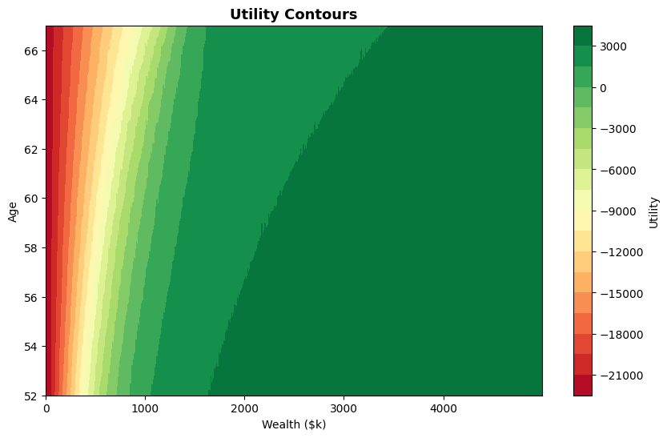

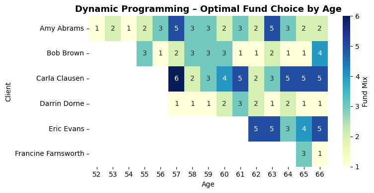

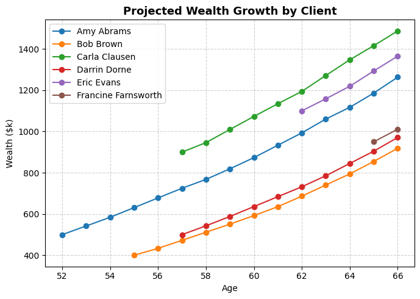

```python
step, N = 5, 100
wealth_levels, DP_util, DP_choice = retirement_dp(step, N)

records = []
for client in clients:
    strategy = find_client_strategy(client, DP_util, DP_choice, wealth_levels, step)
    for age, wealth, fund in strategy:
        records.append({"Client": client["name"], "Age": age, "Wealth (k$)": wealth, "Fund Mix": fund})

df = pd.DataFrame(records)

plot_utility_surface(DP_util, wealth_levels)
plot_fund_heatmap(df)
plot_client_growth(df)
```

For the charts, a finer wealth grid (smaller step) leads to smoother, more detailed utility surfaces. More scenarios ($N$) improve the robustness of expected utilities. Together, these changes can make the results more stable and the optimal decisions more finely tuned to small wealth differences.

#### High-Resolution DP with Many Scenarios

Using a very small step size (e.g., $5$) and a large number of scenarios (e.g., $1000$) creates a highly detailed state space. This setup helps the DP algorithm capture subtle differences in returns and outcomes, resulting in a more sophisticated and potentially more optimal investment path, though at a greater computational cost.

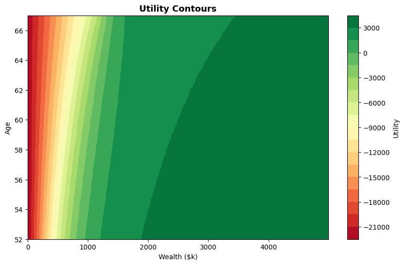

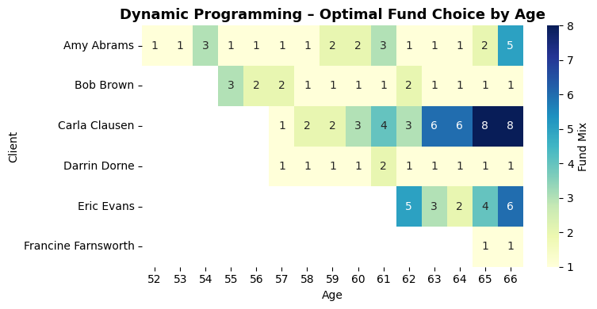

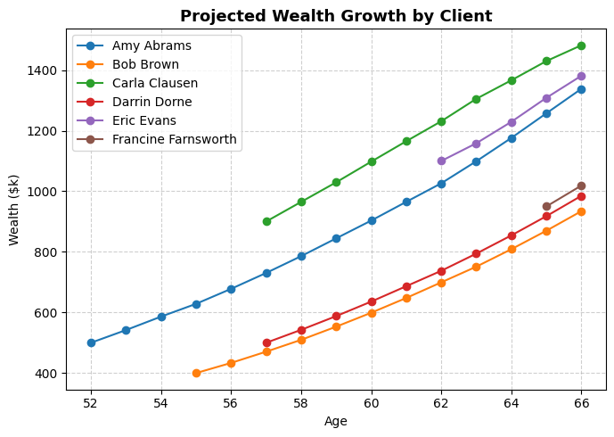

```python
step, N = 5, 1000
wealth_levels, DP_util, DP_choice = retirement_dp(step, N)

records = []
for client in clients:
    strategy = find_client_strategy(client, DP_util, DP_choice, wealth_levels, step)
    for age, wealth, fund in strategy:
        records.append({"Client": client["name"], "Age": age, "Wealth (k$)": wealth, "Fund Mix": fund})

df = pd.DataFrame(records)

plot_utility_surface(DP_util, wealth_levels)
plot_fund_heatmap(df)
plot_client_growth(df)
```

With even higher granularity and more scenarios, the charts become smoother and the patterns in fund choices clearer. The DP solution can now distinguish very small changes in wealth and return distributions, leading to strategies that might, for example, shift from one fund mix to another within a narrow wealth band. This illustrates how parameter tuning can yield more precise and possibly more realistic strategies.

With improved granularity and scenario counts, the strategy can show more selective transitions between mixes at certain wealth thresholds or ages. For instance, a client might remain in a slightly more aggressive mix until just before retirement and then suddenly shift to a safer mix when the marginal utility gain of taking risk is no longer worth the potential shortfall.

#### Final Strategy Simulation

This code block simulates the final chosen strategy across many scenarios to estimate the distribution of final wealth outcomes. It follows the year-by-year fund choices determined by the DP solution and uses random draws from the multivariate normal returns distribution to produce a range of possible retirement outcomes. The final simulation evaluates the distribution of retirement outcomes across thousands of Monte Carlo scenarios.

```python
##############################
# RESULT SIMULATION          #
##############################
def simulate_final_strategy(client, DP_util, DP_choice, funds, mean, covariance, step, N_sim):
    """Monte Carlo simulation of final wealth outcomes given DP strategy."""
    def age_to_index(age): return RETIREMENT_AGE - age
    age, wealth = client['age'], client['current_savings']
    years_to_go = RETIREMENT_AGE - age
    current_wealth_scen = np.full(N_sim, wealth, dtype=float)

    for yr in range(years_to_go):
        current_age_idx = age_to_index(age + yr)
        fund_indices = np.zeros(N_sim, dtype=int)
        for i in range(N_sim):
            w_idx = int(np.floor(current_wealth_scen[i] / step))
            w_idx = np.clip(w_idx, 0, DP_choice.shape[1] - 1)
            fund_indices[i] = DP_choice[current_age_idx, w_idx]

        returns = np.random.multivariate_normal(mean, covariance, size=N_sim)
        total_ret = np.einsum('ij,ij->i', returns, funds[fund_indices])
        current_wealth_scen += annual_saving(age + yr)
        current_wealth_scen *= (1 + total_ret)

    return current_wealth_scen

##############################
# RESULT VISUALIZATION       #
##############################

def plot_final_results(clients, expected_final, median_final, prob):
    """Generate bar and scatter plots for simulated retirement results."""
    x = np.arange(len(clients))
    width = 0.35

    plt.figure(figsize=(7, 5))
    plt.bar(x - width / 2, expected_final, width, label='Expected Final Wealth')
    plt.bar(x + width / 2, median_final, width, label='Median Final Wealth')
    plt.ylabel('Wealth (k)')
    plt.title('Expected vs. Median Final Wealth by Client')
    plt.xticks(x, clients, rotation=45)
    plt.legend()
    plt.tight_layout()
    plt.show()

    plt.figure(figsize=(7, 5))
    plt.bar(clients, prob, color='teal')
    plt.ylabel('Probability of Meeting Target (%)')
    plt.title('Probability of Reaching Financial Goal')
    plt.xticks(rotation=45)
    plt.ylim(0, 100)
    for i, v in enumerate(prob):
        plt.text(i, v + 1, f"{v:.1f}%", ha='center', fontweight='bold')
    plt.tight_layout()
    plt.show()
```

```
Amy Abrams (Age 52):
 Expected final wealth: 1.34k
 Median final wealth: 1.39k
 Probability of meeting target: 47.50%

Bob Brown (Age 55):
 Expected final wealth: 0.98k
 Median final wealth: 0.91k
 Probability of meeting target: 16.30%

Carla Clausen (Age 57):
 Expected final wealth: 1.55k
 Median final wealth: 1.60k
 Probability of meeting target: 69.80%

Darrin Dorne (Age 57):
 Expected final wealth: 1.03k
 Median final wealth: 0.98k
 Probability of meeting target: 19.40%

Eric Evans (Age 62):
 Expected final wealth: 1.41k
 Median final wealth: 1.46k
 Probability of meeting target: 55.90%

Francine Farnsworth (Age 65):
 Expected final wealth: 1.09k
 Median final wealth: 1.09k
 Probability of meeting target: 7.20%
```

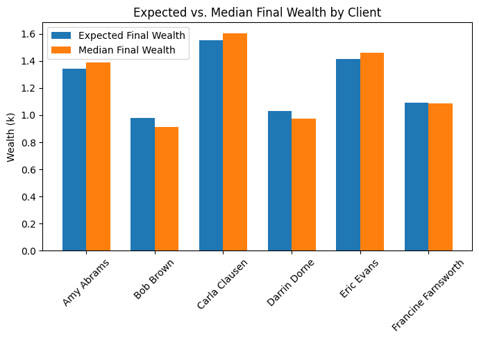

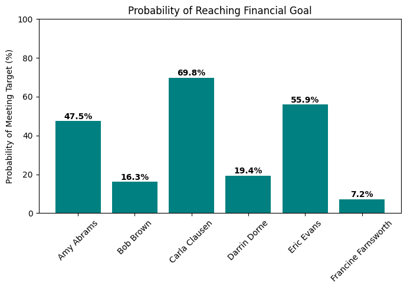

```python
expected_final = []
median_final = []
prob_meet_target = []

for client in clients:
    final_wealths = simulate_final_strategy(client, DP_util, DP_choice, funds, mean, covariance, step, N)
    expected_final.append(np.mean(final_wealths) / 1000)  # in 'k'
    median_final.append(np.median(final_wealths) / 1000)
    prob_meet_target.append(np.mean(final_wealths >= target) * 100)

    print(f"{client['name']} (Age {client['age']}):")
    print(f" Expected final wealth: {expected_final[-1]:.2f}k")
    print(f" Median final wealth: {median_final[-1]:.2f}k")
    print(f" Probability of meeting target: {prob_meet_target[-1]:.2f}%\n")

# Plot results
plot_final_results([c['name'] for c in clients], expected_final, median_final, prob_meet_target)
```

## 5. Discussion of Findings

For clients ahead of their target savings path, the optimal policy emphasizes **stability over additional risk**, preserving wealth through conservative allocations. Conversely, clients trailing their goals may pursue **more aggressive portfolios** to increase their expected terminal wealth—accepting greater volatility in exchange for the chance to “catch up.”

These patterns align with the core tenets of **lifecycle investing** and **modern portfolio theory**, where portfolio risk should decline as the investor’s remaining time to retirement shortens. The utility function’s shortfall-penalty ensures that the trade-off between expected returns and downside risk remains realistic, guiding rational decision-making even under uncertainty.

## 6. Results and Insights

The integrated **dynamic programming and Monte Carlo framework** successfully produces individualized, year-by-year investment recommendations tailored to each client’s age and wealth trajectory.

### Practical Implications

These results can inform financial advisors seeking to balance return potential with goal security. The model quantifies trade-offs between growth and safety and highlights how incremental risk adjustments affect the probability of meeting retirement targets.

## 7. Conclusion

This study demonstrates that **stochastic dynamic programming**, when paired with **Monte Carlo simulation**, provides a powerful and interpretable framework for optimizing retirement portfolios under uncertainty. The resulting strategies balance risk, reward, and goal attainment, reflecting realistic investor behavior across different life stages.

While the current implementation scales approximately as $O(n^3)$ due to nested simulations across ages, wealth levels, and fund options, computational efficiency could be improved through techniques such as vectorization, approximate dynamic programming, or reinforcement-learning-based policy optimization—potentially reducing complexity toward $O(n^2 \log n)$.

Overall, this work illustrates how quantitative optimization can translate complex investment theory into **practical, data-driven retirement advice**. The framework not only enhances financial planning accuracy but also serves as a foundation for future research in adaptive, personalized portfolio management.